# Statistics Final Project R Code

Milena Sargsyan

2025-05-10

```r
df <- readxl::read_excel("C:/Users/user/Downloads/Mandatory Health Insurance.xlsx")
summary(df)
```

```
##    Timestamp                      Ձեր տարիքը / What is your age?
##  Min.   :2025-04-16 21:24:02.77   Length:193
##  1st Qu.:2025-04-16 22:27:49.70   Class :character
##  Median :2025-04-17 00:05:22.75   Mode  :character
##  Mean   :2025-04-17 11:38:01.08
##  3rd Qu.:2025-04-17 16:36:16.50
##  Max.   :2025-04-21 08:58:46.24
##  Որտե՞ղ եք բնակվում / Where do you live? Ձեր բնակավայրը / Your residence area
##  Length:193                              Length:193
##  Class :character                        Class :character
##  Mode  :character                        Mode  :character
##
##
##
##  Որքա՞ն է Ձեր միջին ամսական եկամուտը / What is your approximate monthly income?
##  Length:193
##  Class :character
##  Mode  :character
##
##
##
##  Վերջին 12 ամսվա ընթացքում Ձեզ կամ Ձեր ընտանիքի անդամին անհրաժե՞շտ է եղել բժշկական օգնություն, սակայն հետաձգել կամ խուսափել եք դիմելուց / In the past 12 months, have you or any family member needed medical care but delayed or avoided seeking it?
##  Length:193
##  Class :character
##  Mode  :character
##
##
##
##  Եթե այո, նշել հիմնական պատճառը / If yes, specify the primary reason
##  Length:193
##  Class :character
##  Mode  :character
##
##
##
##  Քանի՞ անգամ եք այցելել բժշկի վերջին 1 տարվա ընթացքում / How many times have you visited a doctor in the past year?
##  Length:193
##  Class :character
##  Mode  :character
##
```

[output cut: 57 more lines]

```
##
##  Նկարագրեք դեպք (եթե եղել է), երբ բժշկական ծախսերը ֆինանսական խնդիրներ են ստեղծել Ձեր ընտանիքի համար /  Describe a situation (if there was one) when medical expenses caused financial difficulties for your family
##  Length:193
##  Class :character
##  Mode  :character
##
##
##
##  Ի՞նչ փոփոխություններ կցանկանայիք տեսնել Հայաստանի առողջապահական համակարգում / What changes would you like to see in Armenia’s healthcare system?
##  Length:193
##  Class :character
##  Mode  :character
##
##
##
```

```r
str(df)
```

```
## tibble [193 × 18] (S3: tbl_df/tbl/data.frame)
##  $ Timestamp                                                                                                                                                                                                                                                                                             …
##  $ Ձեր տարիքը / What is your age?                                                                                                                                                                                                                                                                        …
##  $ Որտե՞ղ եք բնակվում / Where do you live?                                                                                                                                                                                                                                                               …
##  $ Ձեր բնակավայրը / Your residence area                                                                                                                                                                                                                                                                  …
##  $ Որքա՞ն է Ձեր միջին ամսական եկամուտը / What is your approximate monthly income?                                                                                                                                                                                                                        …
##  $ Վերջին 12 ամսվա ընթացքում Ձեզ կամ Ձեր ընտանիքի անդամին անհրաժե՞շտ է եղել բժշկական օգնություն, սակայն հետաձգել կամ խուսափել եք դիմելուց / In the past 12 months, have you or any family member needed medical care but delayed or avoided seeking it?                                                  …
##  $ Եթե այո, նշել հիմնական պատճառը / If yes, specify the primary reason                                                                                                                                                                                                                                   …
##  $ Քանի՞ անգամ եք այցելել բժշկի վերջին 1 տարվա ընթացքում / How many times have you visited a doctor in the past year?                                                                                                                                                                                    …
##  $ Ներկայումս ունե՞ք առողջության ապահովագրություն / Do you currently have health insurance?                                                                                                                                                                                                              …
##  $ Եթե ոչ, նշել հիմնական պատճառը / If not, specify the main reason                                                                                                                                                                                                                                       …
##  $ Միջինում որքա՞ն եք ծախսում առողջապահական ծառայությունների վրա տարեկան՝ ներառյալ դեղորայքը / Annual healthcare spending (approx.), including medications                                                                                                                                               …
##  $ Ի՞նչն եք համարում ՀՀ առողջապահական համակարգի ամենամեծ խնդիրը / What do you consider the biggest problem in Armenia’s healthcare system?                                                                                                                                                               …
##  $ Եթե ՀՀ-ում ներդրվեր առողջության պարտադիր ապահովագրություն՝ ցածր եկամուտ ունեցող ընտանիքների համար սուբսիդավորումներով, ինչպե՞ս կազդեր դա Ձեր՝ առողջապահական ծառայություններից օգտվելու որակի վրա / If mandatory health insurance were introduced in Armenia with subsidies for low-income families, ho…
##  $ Կաջակցե՞ք պարտադիր առողջության ապահովագրության համակարգին, եթե. / Would you support a mandatory health insurance system if:
##
## - Ապահովագրավճարները հիմնվեն եկամտի վրա (ցածր եկամուտ ունեցող ընտանիքները կստանան սուբսիդիաներ) / Premiums were based on income (with subsidies for low-income families)
##                                                         : chr [1:193] "Կաջակցեմ" "Կաջակցեմ" "Չեմ աջակցի" "Կաջակցեմ" ...
##  $ - Ապահովագրությունը ներառի հիմնական ծառայություններ, ինչպիսիք են՝ բժշկի այցելությունները, հոսպիտալացումը և հիմնական դեղորայքը / The insurance covered essential services like doctor visits, hospitalisations, and basic medications
##                                                                                                                                : chr [1:193] "Կաջակցեմ" "Կաջակցեմ" "Կաջակցեմ" "Կաջակցեմ" ...
##  $ Ձեր եկամտի քանի՞ տոկոսն եք պատրաստ վճարել առողջության պարտադիր ապահովագրության համար / What percentage of your income would you be willing to pay for mandatory health insurance?                                                                                                                     …
##  $ Նկարագրեք դեպք (եթե եղել է), երբ բժշկական ծախսերը ֆինանսական խնդիրներ են ստեղծել Ձեր ընտանիքի համար /  Describe a situation (if there was one) when medical expenses caused financial difficulties for your family                                                                                    …
##  $ Ի՞նչ փոփոխություններ կցանկանայիք տեսնել Հայաստանի առողջապահական համակարգում / What changes would you like to see in Armenia’s healthcare system?                                                                                                                                                      …
```

```r
df <- df[, -1]  # remove the Timestamp column

colnames(df) <- c(
  "Age",                    # What is your age?
  "Region",                 # Where do you live?
  "ResidenceType",          # Your residence is in a:
  "MonthlyIncome",          # Monthly income
  "DelayedCare",            # Delayed or avoided care
  "DelayReason",            # Reason for delay
  "DoctorVisits",           # Doctor visits in past year
  "HasInsurance",           # Has insurance
  "NoInsuranceReason",      # Reason no insurance
  "YearlySpending",         # Yearly healthcare spending
  "SystemProblem",          # Biggest problem in healthcare system
  "AccessImpact",           # Impact on access if system implemented
  "SupportIncomeBased",     # Support based on income and subsidies
  "SupportEssentials",      # Support for essential coverage
  "WillingToPay",           # % willing to pay for insurance
  "HardshipStory",          # Financial hardship story (open-ended)
  "SystemChanges"           # Suggested healthcare system changes (open-ended)
)
names(df)
```

```
##  [1] "Age"                "Region"             "ResidenceType"
##  [4] "MonthlyIncome"      "DelayedCare"        "DelayReason"
##  [7] "DoctorVisits"       "HasInsurance"       "NoInsuranceReason"
## [10] "YearlySpending"     "SystemProblem"      "AccessImpact"
## [13] "SupportIncomeBased" "SupportEssentials"  "WillingToPay"
## [16] "HardshipStory"      "SystemChanges"
```

Age Distribution

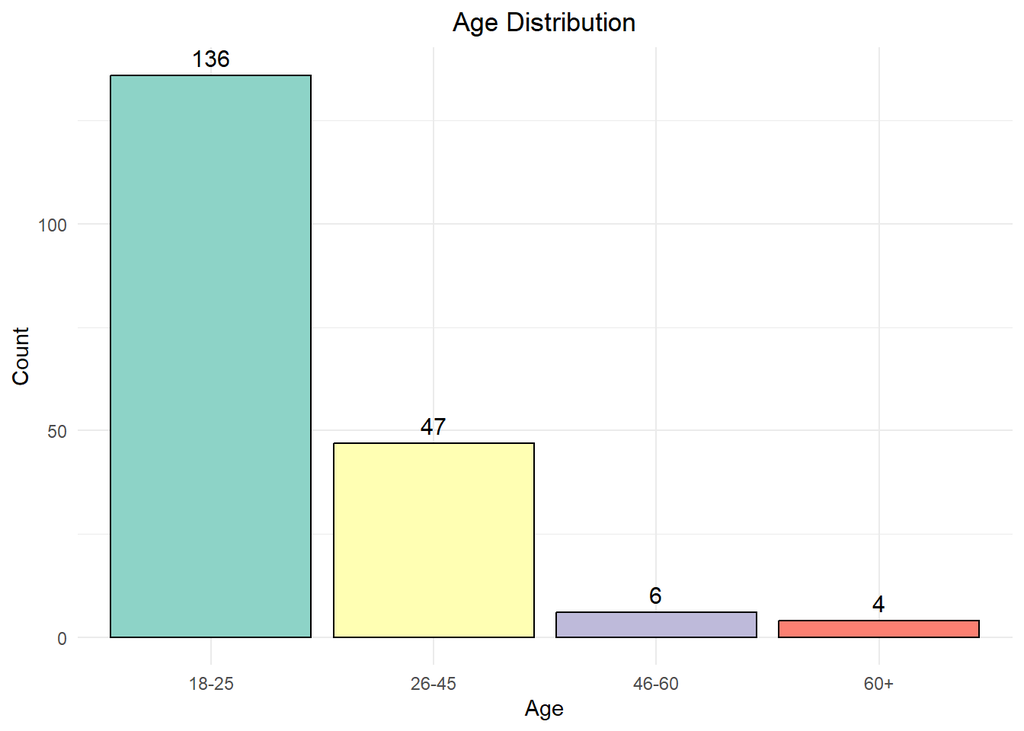

```r
ggplot(df, aes(x = Age, fill = factor(Age))) +
  geom_bar(color = "black") +
  geom_text(stat = "count", aes(label = ..count..), vjust = -0.5, size = 4) +
  scale_fill_brewer(palette = "Set3") +
  labs(title = "Age Distribution", x = "Age", y = "Count") +
  theme_minimal() +
  theme(plot.title = element_text(hjust = 0.5)) +
  guides(fill = "none")
```

Young adults (18-25) dominated responses, reflecting Armenia’s digitally-engaged population but potentially underrepresenting elder care challenges.

Region Distribution

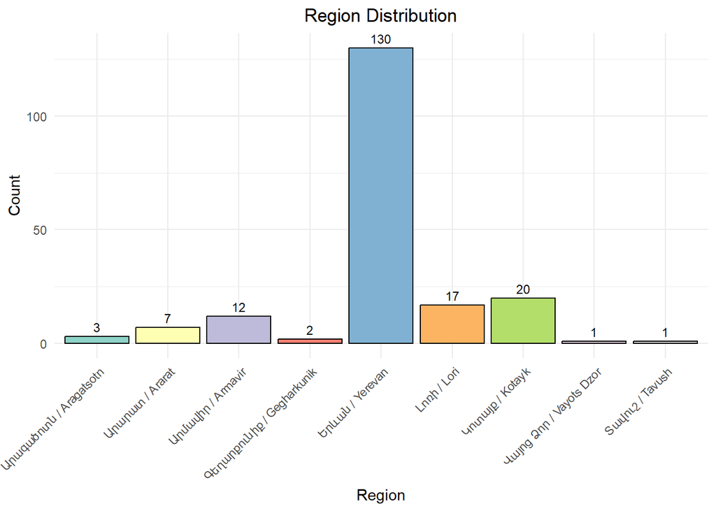

```r
ggplot(df, aes(x = Region, fill = Region)) +
  geom_bar(color = "black") +
  geom_text(stat = "count", aes(label = ..count..), vjust = -0.5, size = 3) +
  scale_fill_brewer(palette = "Set3") +
  labs(title = "Region Distribution", x = "Region", y = "Count") +
  theme_minimal() +
  theme(
    plot.title = element_text(hjust = 0.5),
    axis.text.x = element_text(angle = 45, hjust = 1)
  ) +
  guides(fill = "none")
```

While Yerevan predominates, substantial participation from other regions ensures diverse perspectives.

Residence Type Distribution

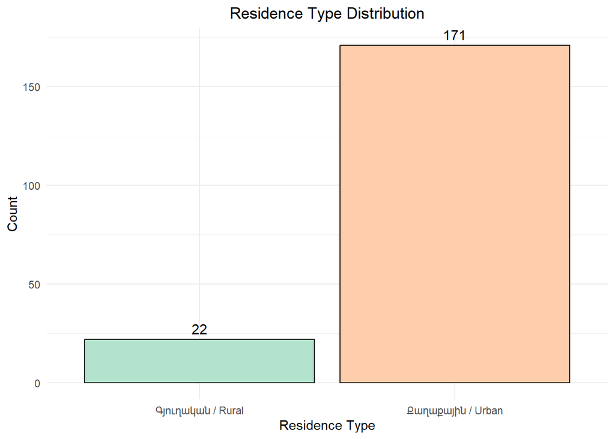

```r
ggplot(df, aes(x = ResidenceType, fill = ResidenceType)) +
  geom_bar(color = "black") +
  geom_text(stat = "count", aes(label = ..count..), vjust = -0.5, size = 4) +
  scale_fill_brewer(palette = "Pastel2") +
  labs(title = "Residence Type Distribution", x = "Residence Type", y = "Count") +
  theme_minimal() +
  theme(
    plot.title = element_text(hjust = 0.5)
  ) +
  guides(fill = "none")
```

While urban respondents predominated, the inclusion of rural perspectives (n=22) provides critical insights into geographic disparities in healthcare access.

Delayed Care by Age

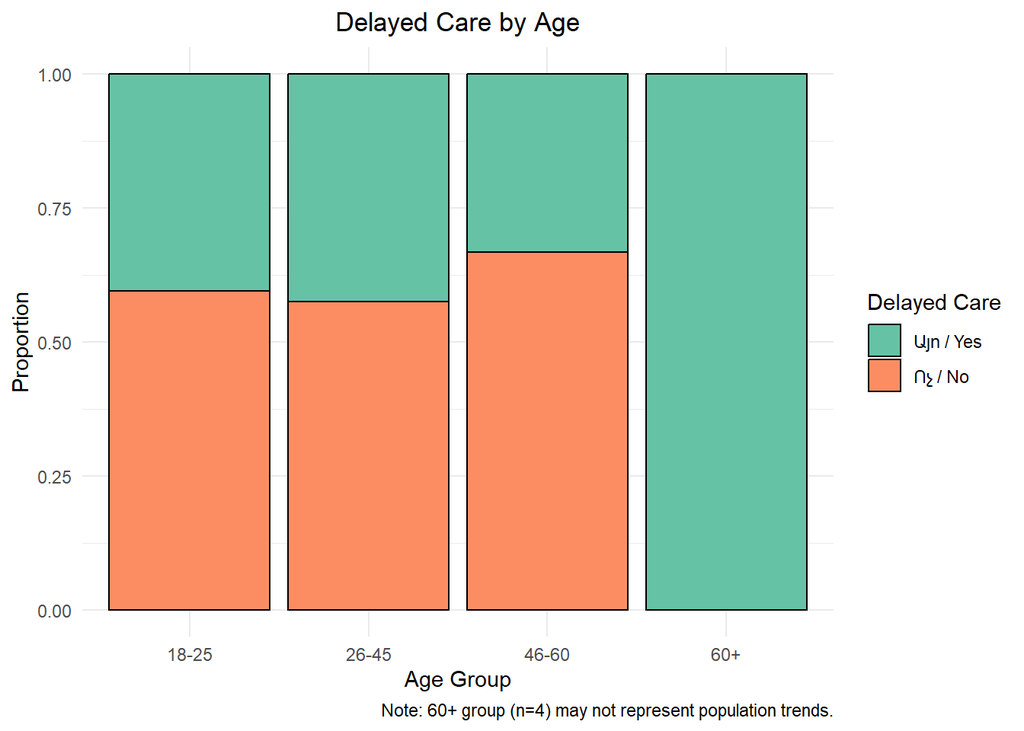

```r
ggplot(df, aes(x = Age, fill = DelayedCare)) +
  geom_bar(position = "fill", color = "black") +
  scale_fill_brewer(palette = "Set2") +
  labs(
    title = "Delayed Care by Age",
    x = "Age Group",
    y = "Proportion",
    fill = "Delayed Care",
    caption = "Note: 60+ group (n=4) may not represent population trends."
  ) +
  theme_minimal() +
  theme(
    plot.title = element_text(hjust = 0.5)
  )
```

Through this barplot, I wanted to figure out if there might be any trends between delaying care and the age. Although, it might visually seem that people aged 60+ appear to delay care more frequently, this observation lacks statistical reliability due to extremely limited data from this demographic. Only 4 survey participants (2.1% of total responses) belonged to the 60+ age group, making any age-specific conclusions about seniors unreliable. However, even if statistically unreliable, the trend aligns with global evidence that seniors face higher healthcare barriers. Therefore, larger studies should target this demographic to verify.

Willingness to Pay by Age

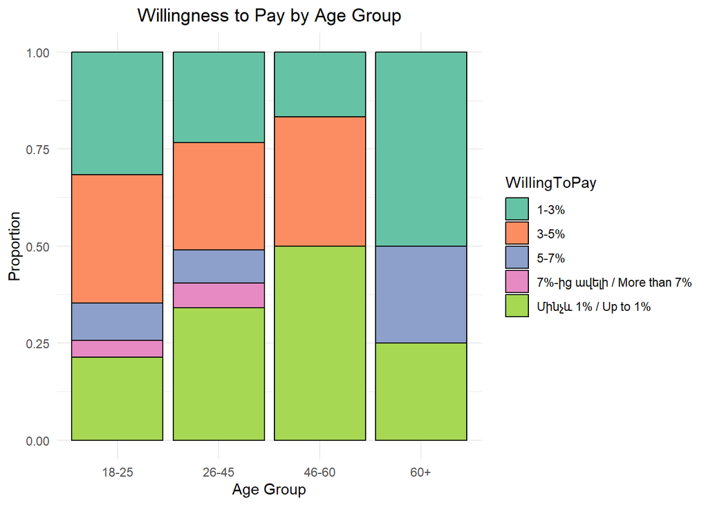

```r
ggplot(df, aes(x = Age, fill = WillingToPay)) +
  geom_bar(position = "fill", color = "black") +
  scale_fill_brewer(palette = "Set2") +
  labs(title = "Willingness to Pay by Age Group", x = "Age Group", y = "Proportion") +
  theme_minimal() +
  theme(
    plot.title = element_text(hjust = 0.5)
  )
```

Through this barplot, I wanted to figure out if the willingness of paying some percentage from income for mandatory health insurance was somehow connected to age. Visually, we might think that the option “up to 1%” is dominating in the combined responses. Which might lead us to think that most people are not willing to pay more than 1% for their health services, therefore raising some questions starting with “WHY?”… However, looking at the auto-generated pie-charts by Google Forms, the actual dominating option is “3-5%” (31.1% of respondents). The actual preference for “3-5%” suggests some willingness to contribute, but affordability limits (low incomes) may cap this. Therefore, just like in the case above, we cannot rely simply on eyeballing to get a full and correct statistical interpretation.

Hypothesis Testing for Delayed Care Based on Residence Type (Urban vs Rural) We want to test if urban residents are more likely to delay seeking care compared to rural residents. Null Hypothesis (H₀): There is no significant difference in the proportion of delayed care cases between urban and rural residents. Alternative Hypothesis (H₁): There is a significant difference in the proportion of delayed care cases between urban and rural residents.

```r
urban_data <- subset(df, ResidenceType == "Քաղաքային / Urban")
rural_data <- subset(df, ResidenceType == "Գյուղական / Rural")

# Count the total number of people in each group
urban_count <- nrow(urban_data)
rural_count <- nrow(rural_data)

# Count of delayed care cases in each group
urban_delayed_count <- sum(urban_data$DelayedCare == "Այո / Yes")
rural_delayed_count <- sum(rural_data$DelayedCare == "Այո / Yes")

# Proportions of delayed care
urban_proportion <- urban_delayed_count / urban_count
rural_proportion <- rural_delayed_count / rural_count
```

Counts and Proportions for each group

```r
cat("Urban residents:", urban_count, "Total with delayed care:", urban_delayed_count, "Proportion:", urban_proportion, "\n")
```

```
## Urban residents: 171 Total with delayed care: 66 Proportion: 0.3859649
```

```r
cat("Rural residents:", rural_count, "Total with delayed care:", rural_delayed_count, "Proportion:", rural_proportion, "\n")
```

```
## Rural residents: 22 Total with delayed care: 15 Proportion: 0.6818182
```

Two-proportion Z-test:

```r
p_pool <- (urban_delayed_count + rural_delayed_count) / (urban_count + rural_count)
SE <- sqrt(p_pool * (1 - p_pool) * (1/urban_count + 1/rural_count))
Z <- (urban_proportion - rural_proportion) / SE
p_value <- 2 * (1 - pnorm(abs(Z)))
```

Print Z and p-value

```r
cat("Z-statistic:", Z, "\n")
```

```
## Z-statistic: -2.64675
```

```r
cat("p-value:", p_value, "\n")
```

```
## p-value: 0.008126944
```

Add CI

```r
prop_test <- prop.test(x = c(urban_delayed_count, rural_delayed_count),
                       n = c(urban_count, rural_count))

# Get 95% CI for the difference in proportions
prop_test$conf.int  # Returns: [lower, upper] difference
```

```
## [1] -0.52936189 -0.06234464
## attr(,"conf.level")
## [1] 0.95
```

Conclusion: Since the p-value (0.0081) is less than 0.05, we reject the null hypothesis at the 5% significance level. This means there is a statistically significant difference in the proportion of delayed care between urban and rural residents. As Z = (urban_proportion - rural_proportion) / SE and given the negative Z-statistic (-2.65), it suggests that urban_proportion < rural_proportion, i.e. urban residents are less likely to delay seeking care compared to rural residents.

Hypothesis Testing for Healthcare Spending Between Insured vs. Uninsured We want to determine whether there is an association between having health insurance (insured vs. uninsured)and the level of annual healthcare spending (e.g., <100K AMD, 100–200K AMD, …, >400K AMD) H₀ (Null Hypothesis): Insurance status and yearly healthcare spending level are independent (no association) H₁ (Alternative Hypothesis): Insurance status and healthcare spending level are associated (dependent)

Here we need to apply the Chi-Square Test of Independence between the two categorical variables Constructing the contingency table

```r
contingency_table1 <- table(df$HasInsurance, df$YearlySpending)
contingency_table1
```

```
##
##             100.000-200.000 դրամ / 100.000-200.000 AMD
##   Այո / Yes                                         15
##   Ոչ / No                                           31
##
##             100.000 դրամից պակաս / Less than 100,000 AMD
##   Այո / Yes                                           27
##   Ոչ / No                                             97
##
##             200.000-300.000 դրամ / 200.000-300.000 AMD
##   Այո / Yes                                          2
##   Ոչ / No                                            9
##
##             300.000-400.000 դրամ / 300.000-400.000 AMD
##   Այո / Yes                                          0
##   Ոչ / No                                            4
##
##             400.000 դրամից ավելի / More than 400.000 AMD
##   Այո / Yes                                            1
##   Ոչ / No                                              7
```

```r
chi_test_result1 <- chisq.test(contingency_table1)
print(chi_test_result1)
```

```
##
##  Pearson's Chi-squared test
##
## data:  contingency_table1
## X-squared = 4.2884, df = 4, p-value = 0.3684
```

Conclusion: Since the p-value (0.3684) > α (0.05), we fail to reject the null hypothesis, therefore at the 5% significance level, there is no statistically significant association between insurance status and yearly healthcare spending. This suggests that, in this sample, whether someone is insured or not does not appear to influence how much they spend annually on healthcare.

Hypothesis Testing for Reasons for Not Having Health Insurance We’re interested in understanding why people don’t have mandatory health insurance, and based on the survey we suspect that lack of awareness is the primary reason. Null Hypothesis (H₀): More than half of the people who do not have health insurance are not primarily unaware of the available options. Alternative Hypothesis (H₁): More than half of the people who do not have health insurance are primarily unaware of the available options.

First, I retrieved the reasons for not having insurance

```r
reasons <- df$NoInsuranceReason
```

However, as the question in the survey was a multiple-answers/checkbox question, some people chose the “Other” option and left it blank, which resulted in missing values in my dataset. That is why, let’s remove NA values and empty strings

```r
reasons_clean <- reasons[!is.na(reasons) & reasons != ""]
reasons_data <- table(reasons_clean)
```

Identifying the number of respondents who are not aware of the possible options for mandatory health insurance

```r
total_count <- sum(reasons_data)
unaware_count <- reasons_data["Տեղյակ չեմ հնարավոր տարբերակների մասին / Not familiar with options"]
other_reasons_count <- total_count - unaware_count
```

```r
cat("People unaware of options:", unaware_count, "\n")
```

```
## People unaware of options: 75
```

```r
cat("Other reasons:", other_reasons_count, "\n")
```

```
## Other reasons: 78
```

Perform one-sample proportion test

```r
prop_test_result <- prop.test(unaware_count, total_count, p = 0.5, alternative = "greater")
prop_test_result
```

```
##
##  1-sample proportions test with continuity correction
##
## data:  unaware_count out of total_count, null probability 0.5
## X-squared = 0.026144, df = 1, p-value = 0.5642
## alternative hypothesis: true p is greater than 0.5
## 95 percent confidence interval:
##  0.4212683 1.0000000
## sample estimates:
##         p
## 0.4901961
```

Conclusion: Since the p-value (0.5642) is greater than the significance level of 0.05, we fail to reject the null hypothesis. This means that there is not enough evidence to conclude that more than half of the people without health insurance are unaware of the available options. The confidence interval [0.4213, 1.0000] also includes 0.5, reinforcing that the observed proportion (49%) is not significantly greater than 50%.

Hypothesis Testing for Support for Mandatory Health Insurance vs Age Group Suppose we want to test whether support for mandatory health insurance (based on the understanding that it would cover essential services such as doctor visits, hospitalizations, and basic medications) is associated with respondents’ age group. H₀ (Null Hypothesis): Support for mandatory health insurance — based on coverage of essential services — is independent of age group. H₁ (Alternative Hypothesis): Support for mandatory health insurance — based on coverage of essential services — is associated with age group.

Here we need to apply the Chi-Square Test of Independence between the two categorical variables Constructing the contingency table

```r
contingency_table2 <- table(df$Age, df$SupportEssentials)
contingency_table2
```

```
##
##         Կաջակցեմ Չեմ աջակցի
##   18-25      124         12
##   26-45       44          3
##   46-60        6          0
##   60+          4          0
```

```r
chi_test_result2 <- chisq.test(contingency_table2)
print(chi_test_result2)
```

```
##
##  Pearson's Chi-squared test
##
## data:  contingency_table2
## X-squared = 1.179, df = 3, p-value = 0.758
```

Conclusion: Since the p-value (0.758) > 0.05, we fail to reject the null hypothesis. Based on the Chi-Square Test of Independence results, we fail to reject the null hypothesis. This suggests that there is no statistically significant association between respondents’ age group and their support for mandatory health insurance. In other words, support for mandatory health insurance appears to be independent of age group.